# Class 2 Problem Set

POS6933: Computational Social Science

Truscott (Spring 2026)

**Note**: Students should always aim to produce *publication-worthy* tables and figures. Unless otherwise stated, tables should be rendered using `stargazer::()`, while figures can be rendered using `ggplot2::()` or `plot()`. Regardless, tables and figures should always be presented with necessary formatting – e.g., (sub)title, axis (variable) labels and titles, a clearly-identifiable legend and key, etc. Problem sets must always be compiled using `LaTex` or `RMarkdown` and include the full coding routine (with notes explaining your implementation) used to complete each problem (10pts).

1. Generate 1000 random numbers from a uniform distribution between zero and one. Do the same from a standard normal distribution where $\mu$ = 5 and $\sigma = 2.5$. Plot the results separately but in the same plot window using `cowplot::()` or similar. (2pts)

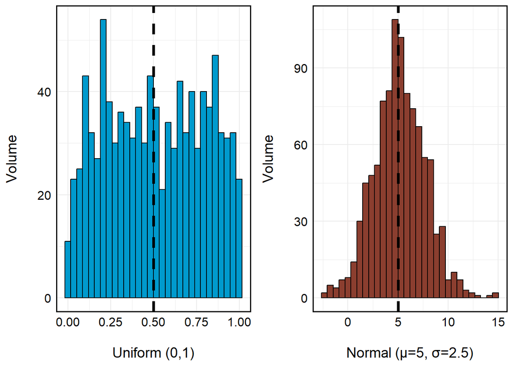

```r
set.seed(4421) # Set Random Seed

a <- runif(1000, min = 0, max = 1)  # Uniform Distribution
b <- rnorm(1000, mean = 5, sd = 2.5) # Standard Normal (Mean = 5, SD = 2.5)

plot_a <- ggplot(data.frame(x = a), aes(x)) +
  geom_histogram(bins = 30, fill = "deepskyblue3", color = "black") +
  labs(x = "\nUniform (0,1)",
       y = 'Volume\n') +
  geom_vline(xintercept = 0.5, linetype = 2, linewidth = 1.25) +
  theme_minimal() +
  theme(panel.border = element_rect(linewidth = 1, colour = 'black', fill = NA),
        axis.text = element_text(size = 12, colour = 'black'),
        axis.title = element_text(size = 14, colour = 'black'))# Plot A

plot_b <- ggplot(data.frame(x = b), aes(x)) +
  geom_histogram(bins = 30, fill = "coral4", color = "black") +
  labs(x = "\nNormal (μ=5, σ=2.5)",
       y = 'Volume\n') +
  geom_vline(xintercept = 5, linetype = 2, linewidth = 1.25) +
  theme_minimal() +
  theme(panel.border = element_rect(linewidth = 1, colour = 'black', fill = NA),
        axis.text = element_text(size = 12, colour = 'black'),
        axis.title = element_text(size = 14, colour = 'black')) # Plot B


cowplot::plot_grid(plot_a, plot_b) # Combine to Single Plot Grd
```

```r
set.seed(4421) # Set Random Seed

probs <- c(rep(1/7, 5), 2/7) # 6 = 2*p, so 1-5 = 1/7 & 6 = 2/7
rolls <- as.data.frame(table(sample(1:6, size = 1000, replace = TRUE, prob = probs))) %>% # Simulate Rolls (& Convert to DF)
   setNames(c("side", "count")) %>% # Assign Column Names
  mutate(proportion = count/sum(count),
         prob = probs) # Recover Proportion

rolls %>%
  mutate(proportion = count/sum(count)) # Proportion & Probs
```

```
##   side count proportion      prob
## 1    1   143      0.143 0.1428571
## 2    2   160      0.160 0.1428571
## 3    3   142      0.142 0.1428571
## 4    4   137      0.137 0.1428571
## 5    5   141      0.141 0.1428571
## 6    6   277      0.277 0.2857143
```

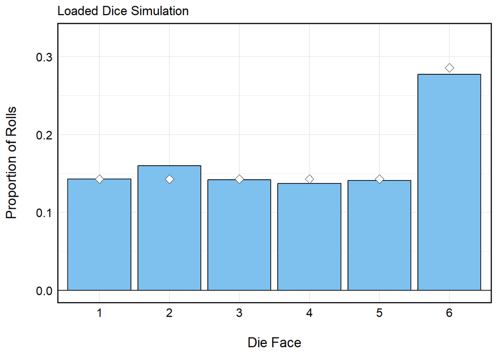

```r
rolls %>%
  ggplot(aes(x = factor(side), y = proportion)) +
  geom_bar(stat = "identity", fill = "skyblue2", colour = 'black') +
  geom_point(aes(y = prob), color = "black", fill = 'white', shape = 23, size = 3) +
  geom_hline(yintercept = 0) +
  labs(x = "\nDie Face",
       y = "Proportion of Rolls\n",
       title = 'Loaded Dice Simulation') +
  scale_y_continuous(limits = c(0, max(rolls$proportion) + 0.05)) +
  theme_minimal() +
  theme(panel.border = element_rect(linewidth = 1, colour = 'black', fill = NA),
        axis.text = element_text(size = 12, colour = 'black'),
        axis.title = element_text(size = 14, colour = 'black'))
```

3. Imagine two children are playing a rock-paper-scissors game for pennies. At the start of the game, both Player 1 and Player 2 have 50¢. Each time they play, the winner receives 1 cent from the loser – they will continue playing until one of them has $1. Simulate the progression of this game 1,000 times, such that either Player 1 or Player 2 will conclude a game with the dollar. Plot the distribution of times Player 1 wins versus Player 2. (2pts)

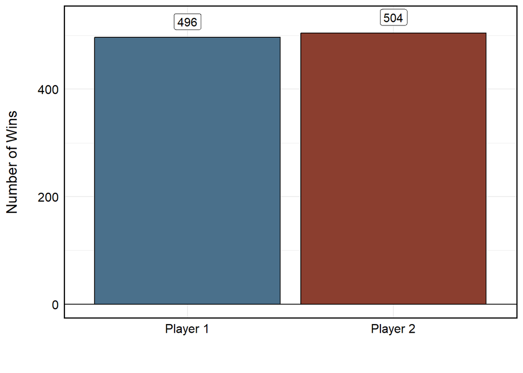

```r
set.seed(4421) # Set Random Seed

play_game <- function() {
  player_1 <- 50 # Starting $0.50
  player_2 <- 50 # Starting $0.50
  while (player_1 > 0 && player_2 > 0) {
    outcome <- sample(c(-1, 0, 1), size = 1, prob = c(0.45, 0.10, 0.45)) # Sim Single RPS Winner: 1 = P1, -1 = P2, 0 = Tie
    if (outcome == 1) { # If Player 1 Wins
      player_1 <- player_1 + 1 # Add 1 cent to P1
      player_2 <- player_2 - 1
    } else if (outcome == -1) { # If Player 2 Wins
      player_1 <- player_1 - 1
      player_2 <- player_2 + 1 # Add 1 cent to P2
    } # (Move on if Tie)
  }
  if (player_1 == 100) return("Player 1") # If P1 gets $1 -- Return their Name
  if (player_2 == 100) return("Player 2") # If P2 gets $1 -- Reutrn their Name


  } # Function to Simulate Rock-Paper-Scissors Until 1 Player has $1

n_sim <- 1000 # Number of Simulations to Run (1k)
results <- c() # Empty List to Store Output (Could Also Use replicate(1000, play_game()))

for (i in 1:n_sim){
  temp_winner <- play_game()
  results <- c(results, temp_winner)
}

data.frame(table(results)) %>%
  setNames(c('player', 'frequency')) %>%
  ggplot(aes(x = player, y = frequency)) +
  geom_col(aes(fill = player), colour = 'black') +
  scale_fill_manual(values = c('skyblue4', 'coral4')) +
  geom_hline(yintercept = 0) +
  geom_label(aes(label = frequency), vjust = -0.5, size = 4) +
  scale_y_continuous(limits = c(0, max(data.frame(table(results))$Freq) + 25)) +
  labs(x = '\n ',
      y = 'Number of Wins\n') +
  theme_minimal() +
  theme(panel.border = element_rect(linewidth = 1, colour = 'black', fill = NA),
        axis.text = element_text(size = 12, colour = 'black'),
        axis.title = element_text(size = 14, colour = 'black'),
        legend.position = 'none')
```

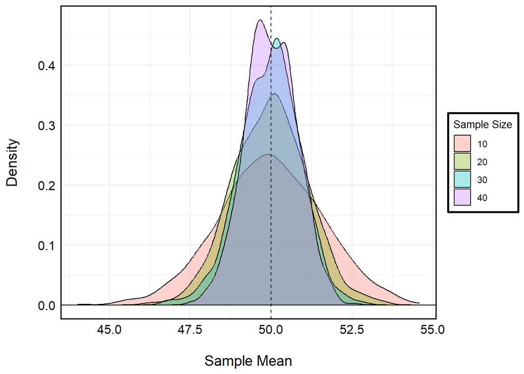

```r
set.seed(4421) # Set Random Seed

mu <- 50 # Mean
sigma <- 5 # SD
n_sim <- 1000 # Simulations Count
means_combined <- data.frame() # Empty DF to Store Output

for (i in seq(10, 40, 10)){
  temp_mean <- replicate(n_sim, mean(rnorm(i, mean = mu, sd = sigma))) # Temp Run (i Samples)
  temp_mean <- data.frame(mean = temp_mean,
                          samples = i) # Combine to Temp DF
  means_combined <- bind_rows(means_combined, temp_mean) # Export to DF
} # Run Individual Sample Sizes -- Export to means_combined

means_combined %>%
  mutate(samples = as.factor(samples)) %>%
  ggplot(aes(x = mean, group = samples)) +
  geom_density(aes(fill = samples), alpha = 1/3) +
  geom_hline(yintercept = 0) +
  geom_vline(xintercept = 50, linetype = 2) +
  labs(x = '\nSample Mean',
       y = 'Density\n',
       fill = 'Sample Size') +
  theme_minimal() +
  theme(panel.border = element_rect(linewidth = 1, colour = 'black', fill = NA),
        axis.text = element_text(size = 12, colour = 'black'),
        axis.title = element_text(size = 14, colour = 'black'),
        legend.position = 'right',
        legend.title = element_text(size = 10, colour = 'black', vjust = 0.5),
        legend.background = element_rect(linewidth = 1, colour = 'black', fill = NA))
```

5. A call center receives customer calls at a rate of one every 5 minutes, on average. The time between calls can be modeled using an exponential distribution with a mean of 5 minutes. Simulate 1,000 inter-arrival times (in minutes) for incoming calls. Plot the distributions of simulated times and overlay the theoretical exponential density curve. Estimate the probability that the next call arrives within 3 minutes. (2pts)

```r
set.seed(4421) # Random Seed Generation
mu <- 5 # 5 Min Mean
calls <- data.frame(rexp(1000, rate = 1/mu)) %>%
  setNames('arrival_time') # 1000 Sims (Rate = 1/Avg. Time)

mean(calls <= 3) # Prob <=3 Min
```

```
## [1] 0.437
```

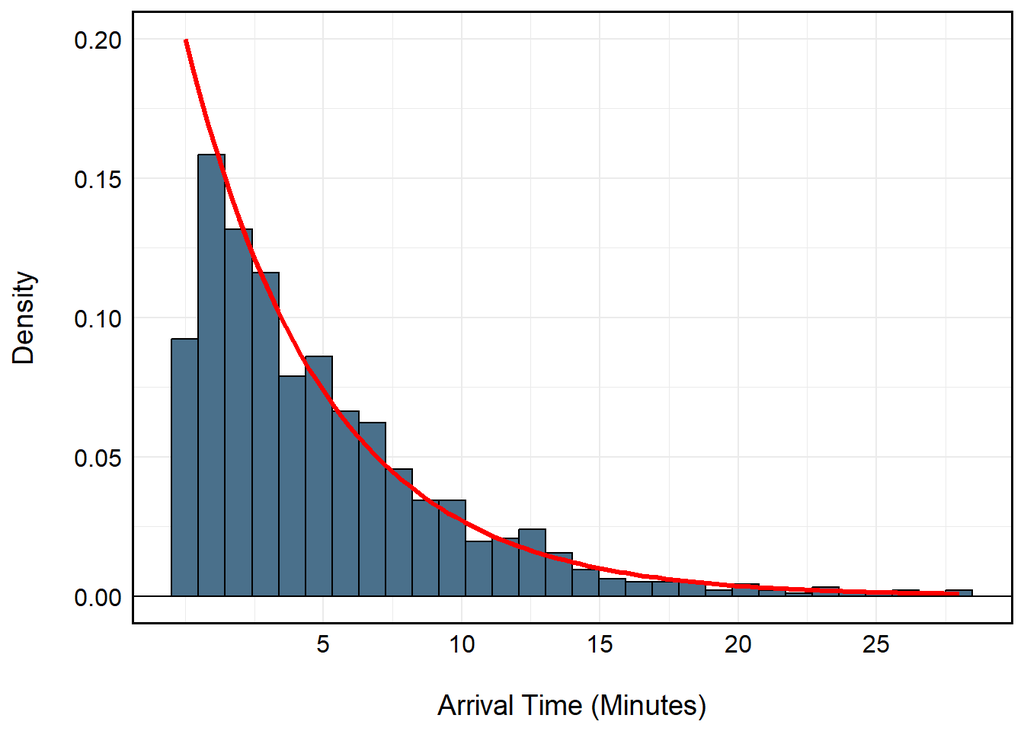

```r
calls %>%
  ggplot(aes(x = arrival_time)) +
  geom_histogram(aes(y = after_stat(density)), bins = 30,
               fill = 'skyblue4', colour = 'black') +
  stat_function(fun = dexp, args = list(rate = 1/mu), colour = "red", linewidth = 1.2) + # Plot Theoretical Distribution Too
  geom_hline(yintercept = 0) +
  labs(x = "\nArrival Time (Minutes)",
       y = "Density\n") +
    theme_minimal() +
  scale_x_continuous(breaks = seq(5, 30, 5)) +
  theme(panel.border = element_rect(linewidth = 1, colour = 'black', fill = NA),
        axis.text = element_text(size = 12, colour = 'black'),
        axis.title = element_text(size = 14, colour = 'black'),
        legend.position = 'right',
        legend.title = element_text(size = 10, colour = 'black', vjust = 0.5),
        legend.background = element_rect(linewidth = 1, colour = 'black', fill = NA))
```